# Stat240Proj

#Introduction

Urbanization and population growth are two defining trends of modern society. As cities expand, demographic patterns,such as the balance between male and female residents, may change due to differences in migration, employment, and cultural factors. Research Question: Does city size which measured by total population affect the gender composition in cities worldwide, specifically the proportion of males and females? To answer this, we use official United Nations city-level population data and compare the average proportion of females between large and small cities using statistical inference.

#Data Description

The data come from the United Nations Department of Economic and Social Affairs (UN DESA) “World Urbanization Prospects” dataset. The dataset provides estimated city populations by sex and year, based on census and survey data.

We use two files: unsd-citypopulation-year-fm.csv: contains male and female population counts for each city and year unsd-citypopulation-year-both.csv: contains total population counts for each city and year Variable Descriptions

| Variable | Description |
| --- | --- |
| **City** | City name |
| **Year** | Year of observation |
| **Sex** | “Male” or “Female” |
| **Value** | Population count |

We focus on 2020, the most recent year with complete data.

```r
both <- read_csv("unsd-citypopulation-year-both.csv")
fm <- read_csv("unsd-citypopulation-year-fm.csv")


both_2020 <- both %>% filter(Year == 2020)
fm_2020 <- fm %>% filter(Year == 2020)


fm_wide <- fm_2020 %>%
  pivot_wider(names_from = Sex, values_from = Value) %>%
  rename(male = Male, female = Female)


city_data <- fm_wide %>%
  left_join(both_2020 %>% select(City, Value), by = "City") %>%
  rename(total = Value)

city_data <- city_data %>%
  mutate(female_prop = female / total,
         size_group = ifelse(total > median(total, na.rm = TRUE),
                             "Large City", "Small/Medium City"))

city_data <- city_data %>% drop_na(female_prop)

glimpse(city_data)
```

```
## Rows: 2,385
## Columns: 14
## $ `Country or Area` <chr> "Åland Islands", "Argentina", "Argentina", "Argentin…
## $ Year              <chr> "2020", "2020", "2020", "2020", "2020", "2020", "202…
## $ Area              <chr> "Total", "Total", "Total", "Total", "Total", "Total"…
## $ City              <chr> "MARIEHAMN", "Bahía Blanca-Cerri", "BUENOS AIRES", "…
## $ `City type`       <chr> "City proper", "Urban agglomeration", "Urban agglome…
## $ `Record Type`     <chr> "Estimate - de jure", "Estimate - de facto", "Estima…
## $ Reliability       <chr> "Final figure, complete", "Final figure, complete", …
## $ `Source Year`     <dbl> 2021, 2020, 2020, 2020, 2020, 2020, 2020, 2020, 2020…
## $ `Value Footnotes` <dbl> 1, 4, 4, 4, 4, 4, 4, 4, 4, 4, 4, 4, 4, 4, 4, 4, 4, 4…
## $ male              <dbl> 5599.50, 151493.94, 7518759.15, 108357.24, 121191.48…
## $ female            <dbl> 6092.00, 163044.66, 7897969.16, 114626.79, 115245.03…
## $ total             <dbl> 11692.0, 314538.6, 15416728.3, 222984.0, 236436.5, 1…
## $ female_prop       <dbl> 0.5210400, 0.5183614, 0.5122987, 0.5140583, 0.487424…
## $ size_group        <chr> "Small/Medium City", "Large City", "Large City", "La…
```

#Exploratory Visualization We first visualize how the female proportion differs between large and small cities. The boxplot compares the proportion of female residents between large and smaller cities. We can observe whether large cities generally have higher or lower female representation.

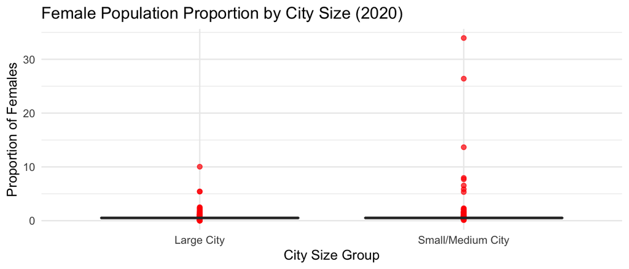

```r
ggplot(city_data, aes(x = size_group, y = female_prop, fill = size_group)) +
  geom_boxplot(alpha = 0.7, outlier.color = "red") +
  labs(title = "Female Population Proportion by City Size (2020)",
       x = "City Size Group", y = "Proportion of Females") +
  theme_minimal() +
  theme(legend.position = "none")
```

#Statistical Analysis We test whether there is a statistically significant difference in average female proportion between large and small cities.

Hypotheses: H0: μ_large = μ_small (The average proportion of females is the same in large and small cities.) Ha: μ_large ≠ μ_small (The average proportion of females differs between large and small cities.) We perform a two-sample t-test for comparing two population means

```r
t_result <- t.test(female_prop ~ size_group, data = city_data, var.equal = FALSE)
t_result
```

```
##
##  Welch Two Sample t-test
##
## data:  female_prop by size_group
## t = -2.4648, df = 1396.7, p-value = 0.01383
## alternative hypothesis: true difference in means between group Large City and group Small/Medium City is not equal to 0
## 95 percent confidence interval:
##  -0.18117603 -0.02059509
## sample estimates:
##        mean in group Large City mean in group Small/Medium City
##                       0.5312375                       0.6321230
```

The p-value from the test indicates whether there is evidence of a difference in female proportions between city sizes. If p < 0.05, we reject H₀ and conclude that city size has a statistically significant association with gender composition.

We use the median city population as the cutoff to define “large” and “small/medium” cities. This ensures that the two groups have similar sample sizes, which improves the reliability of the t-test.

We can also build a 95% confidence interval for the difference in mean proportions:

```r
t_result$conf.int
```

```
## [1] -0.18117603 -0.02059509
## attr(,"conf.level")
## [1] 0.95
```

Summary of Key Results

[output not shown]

#Conclusion

[output not shown]